# Campus Recruitment (kaggle)- Academic and Employability Factors influencing placement

# January 2022

# Introduction

The dataset has been taken from https://www.kaggle.com/benroshan/factors-affecting-campus-placement and included the following columns:

**sl_no** Serial Number  
**Gender** - Male='M',Female='F'  
**ssc_p** Secondary Education percentage- 10th Grade  
**ssc_b** Board of Education- Central/ Others  
**hsc_p** Higher Secondary Education percentage- 12th Grade  
**hsc_b** Board of Education- Central/ Others  
**hsc_s** Specialization in Higher Secondary Education  
**degree_p** Degree Percentage  
**degree_t** Under Graduation(Degree type)- Field of degree education  
**workex** Work Experience  
**etest_p** Employability test percentage ( conducted by college)  
**specialisation** Post Graduation(MBA)- Specialization  
**mba_p** MBA percentage  
**status** Status of placement- Placed/Not placed  
**salary** Salary offered by corporate to candidates

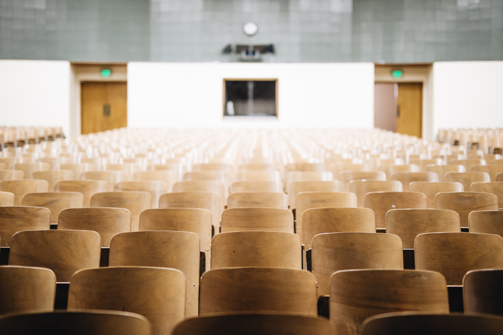

```python
#Photo by Nathan Dumlao on Unsplash
from IPython import display
from PIL import Image
display.Image("campus.jpg")
```

# Data Importing

```python
#import data/ drop not needed columns
import pandas as pd
import numpy as np

students = pd.read_csv('Placement_Data_Full_Class.csv')
students
```

|  | sl_no | gender | ssc_p | ssc_b | hsc_p | hsc_b | hsc_s | degree_p | degree_t | workex | etest_p | specialisation | mba_p | status | salary |
| --- | --- | --- | --- | --- | --- | --- | --- | --- | --- | --- | --- | --- | --- | --- | --- |
| 0 | 1 | M | 67.00 | Others | 91.00 | Others | Commerce | 58.00 | Sci&Tech | No | 55.0 | Mkt&HR | 58.80 | Placed | 270000.0 |
| 1 | 2 | M | 79.33 | Central | 78.33 | Others | Science | 77.48 | Sci&Tech | Yes | 86.5 | Mkt&Fin | 66.28 | Placed | 200000.0 |
| 2 | 3 | M | 65.00 | Central | 68.00 | Central | Arts | 64.00 | Comm&Mgmt | No | 75.0 | Mkt&Fin | 57.80 | Placed | 250000.0 |
| 3 | 4 | M | 56.00 | Central | 52.00 | Central | Science | 52.00 | Sci&Tech | No | 66.0 | Mkt&HR | 59.43 | Not Placed | NaN |
| 4 | 5 | M | 85.80 | Central | 73.60 | Central | Commerce | 73.30 | Comm&Mgmt | No | 96.8 | Mkt&Fin | 55.50 | Placed | 425000.0 |
| ... | ... | ... | ... | ... | ... | ... | ... | ... | ... | ... | ... | ... | ... | ... | ... |
| 210 | 211 | M | 80.60 | Others | 82.00 | Others | Commerce | 77.60 | Comm&Mgmt | No | 91.0 | Mkt&Fin | 74.49 | Placed | 400000.0 |
| 211 | 212 | M | 58.00 | Others | 60.00 | Others | Science | 72.00 | Sci&Tech | No | 74.0 | Mkt&Fin | 53.62 | Placed | 275000.0 |
| 212 | 213 | M | 67.00 | Others | 67.00 | Others | Commerce | 73.00 | Comm&Mgmt | Yes | 59.0 | Mkt&Fin | 69.72 | Placed | 295000.0 |
| 213 | 214 | F | 74.00 | Others | 66.00 | Others | Commerce | 58.00 | Comm&Mgmt | No | 70.0 | Mkt&HR | 60.23 | Placed | 204000.0 |
| 214 | 215 | M | 62.00 | Central | 58.00 | Others | Science | 53.00 | Comm&Mgmt | No | 89.0 | Mkt&HR | 60.22 | Not Placed | NaN |

215 rows × 15 columns

```python
#check for missing values, only in  the salary we have missing values but I will not use it in any case
students.info()
```

```
<class 'pandas.core.frame.DataFrame'>
RangeIndex: 215 entries, 0 to 214
Data columns (total 15 columns):
 #   Column          Non-Null Count  Dtype
---  ------          --------------  -----
 0   sl_no           215 non-null    int64
 1   gender          215 non-null    object
 2   ssc_p           215 non-null    float64
 3   ssc_b           215 non-null    object
 4   hsc_p           215 non-null    float64
 5   hsc_b           215 non-null    object
 6   hsc_s           215 non-null    object
 7   degree_p        215 non-null    float64
 8   degree_t        215 non-null    object
 9   workex          215 non-null    object
 10  etest_p         215 non-null    float64
 11  specialisation  215 non-null    object
 12  mba_p           215 non-null    float64
 13  status          215 non-null    object
 14  salary          148 non-null    float64
dtypes: float64(6), int64(1), object(8)
memory usage: 25.3+ KB
```

# Exploratory Data Analysis

I start with a quick exploratory data analysis to understand the data

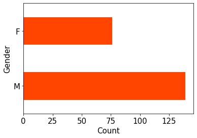

```python
import matplotlib.pyplot as plt
plt.rcParams.update({'font.size': 15})
students['gender'].value_counts().plot(kind='barh', color='orangered')
plt.xlabel('Count')
plt.ylabel('Gender')
```

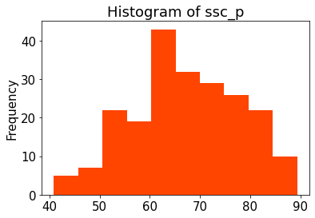

```python
students['ssc_p'].plot(kind='hist', color='orangered')
plt.title('Histogram of ssc_p')
plt.show()
```

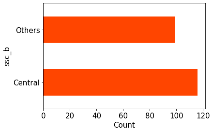

```python
students['ssc_b'].value_counts().plot(kind='barh', color='orangered')
plt.xlabel('Count')
plt.ylabel('ssc_b')
```

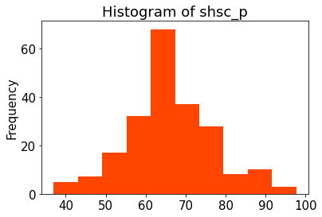

```python
students['hsc_p'].plot(kind='hist', color='orangered')
plt.title('Histogram of shsc_p')
plt.show()
```

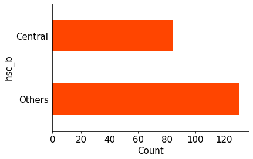

```python
students['hsc_b'].value_counts().plot(kind='barh', color='orangered')
plt.xlabel('Count')
plt.ylabel('hsc_b')
```

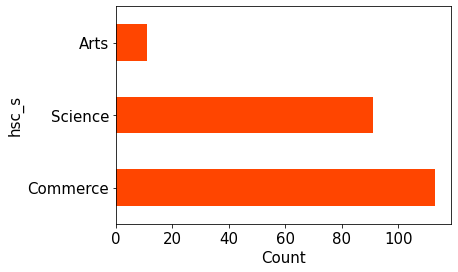

```python
students['hsc_s'].value_counts().plot(kind='barh', color='orangered')
plt.xlabel('Count')
plt.ylabel('hsc_s')
```

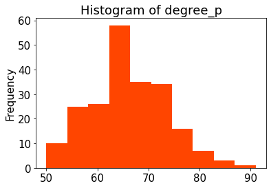

```python
students['degree_p'].plot(kind='hist', color='orangered')
plt.title('Histogram of degree_p')
plt.show()
```

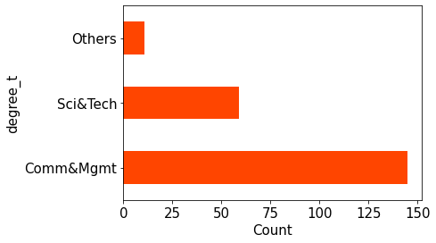

```python
students['degree_t'].value_counts().plot(kind='barh', color='orangered')
plt.xlabel('Count')
plt.ylabel('degree_t')
```

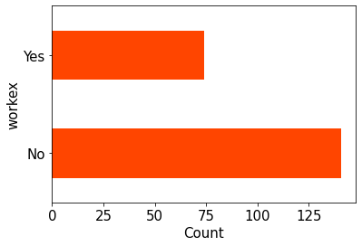

```python
students['workex'].value_counts().plot(kind='barh', color='orangered')
plt.xlabel('Count')
plt.ylabel('workex')
```

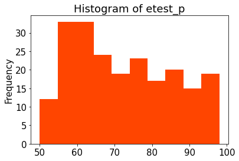

```python
students['etest_p'].plot(kind='hist', color='orangered')
plt.title('Histogram of etest_p')
plt.show()
```

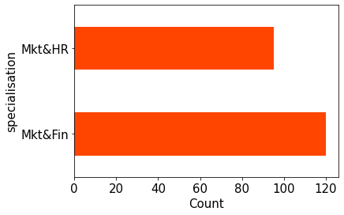

```python
students['specialisation'].value_counts().plot(kind='barh', color='orangered')
plt.xlabel('Count')
plt.ylabel('specialisation')
```

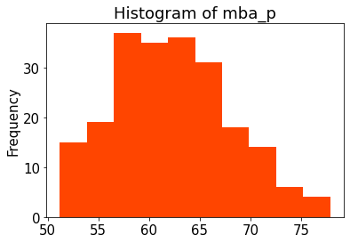

```python
students['mba_p'].plot(kind='hist', color='orangered')
plt.title('Histogram of mba_p')
plt.show()
```

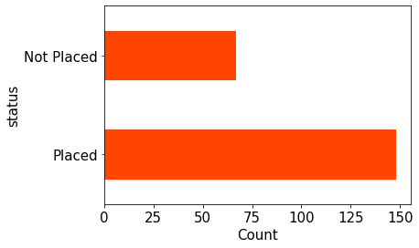

```python
students['status'].value_counts().plot(kind='barh', color='orangered')
plt.xlabel('Count')
plt.ylabel('status')
```

# Data Preprocessing

```python
#create a copy
students_copy = students.copy()
#drop not needed columns
students_copy=students_copy.drop(columns = ['sl_no','salary'])
#replace binary columns with 1 and 0
from sklearn.preprocessing import LabelEncoder
le = LabelEncoder()
students_copy["gender"] = le.fit_transform(students_copy["gender"])
students_copy["ssc_b"] = le.fit_transform(students_copy["ssc_b"])
students_copy["hsc_b"] = le.fit_transform(students_copy["hsc_b"])
students_copy["workex"] = le.fit_transform(students_copy["workex"])
students_copy["specialisation"] = le.fit_transform(students_copy["specialisation"])
students_copy["status"] = le.fit_transform(students_copy["status"])
#one hot encoding from hsc_s and degree_t
students_copy = pd.get_dummies(students_copy, columns=['hsc_s'], drop_first = True)
students_copy = pd.get_dummies(students_copy, columns=['degree_t'], drop_first = True)

students_copy
```

|  | gender | ssc_p | ssc_b | hsc_p | hsc_b | degree_p | workex | etest_p | specialisation | mba_p | status | hsc_s_Commerce | hsc_s_Science | degree_t_Others | degree_t_Sci&Tech |
| --- | --- | --- | --- | --- | --- | --- | --- | --- | --- | --- | --- | --- | --- | --- | --- |
| 0 | 1 | 67.00 | 1 | 91.00 | 1 | 58.00 | 0 | 55.0 | 1 | 58.80 | 1 | 1 | 0 | 0 | 1 |
| 1 | 1 | 79.33 | 0 | 78.33 | 1 | 77.48 | 1 | 86.5 | 0 | 66.28 | 1 | 0 | 1 | 0 | 1 |
| 2 | 1 | 65.00 | 0 | 68.00 | 0 | 64.00 | 0 | 75.0 | 0 | 57.80 | 1 | 0 | 0 | 0 | 0 |
| 3 | 1 | 56.00 | 0 | 52.00 | 0 | 52.00 | 0 | 66.0 | 1 | 59.43 | 0 | 0 | 1 | 0 | 1 |
| 4 | 1 | 85.80 | 0 | 73.60 | 0 | 73.30 | 0 | 96.8 | 0 | 55.50 | 1 | 1 | 0 | 0 | 0 |
| ... | ... | ... | ... | ... | ... | ... | ... | ... | ... | ... | ... | ... | ... | ... | ... |
| 210 | 1 | 80.60 | 1 | 82.00 | 1 | 77.60 | 0 | 91.0 | 0 | 74.49 | 1 | 1 | 0 | 0 | 0 |
| 211 | 1 | 58.00 | 1 | 60.00 | 1 | 72.00 | 0 | 74.0 | 0 | 53.62 | 1 | 0 | 1 | 0 | 1 |
| 212 | 1 | 67.00 | 1 | 67.00 | 1 | 73.00 | 1 | 59.0 | 0 | 69.72 | 1 | 1 | 0 | 0 | 0 |
| 213 | 0 | 74.00 | 1 | 66.00 | 1 | 58.00 | 0 | 70.0 | 1 | 60.23 | 1 | 1 | 0 | 0 | 0 |
| 214 | 1 | 62.00 | 0 | 58.00 | 1 | 53.00 | 0 | 89.0 | 1 | 60.22 | 0 | 0 | 1 | 0 | 0 |

215 rows × 15 columns

```python
#standarize not binary columns
from sklearn.preprocessing import StandardScaler

col_names = ["ssc_p", "hsc_p","degree_p", "etest_p", "mba_p" ]
features = students_copy[col_names]
scaler = StandardScaler().fit(features.values)
features = scaler.transform(features.values)

students_copy[col_names] = features
students_copy
```

|  | gender | ssc_p | ssc_b | hsc_p | hsc_b | degree_p | workex | etest_p | specialisation | mba_p | status | hsc_s_Commerce | hsc_s_Science | degree_t_Others | degree_t_Sci&Tech |
| --- | --- | --- | --- | --- | --- | --- | --- | --- | --- | --- | --- | --- | --- | --- | --- |
| 0 | 1 | -0.028087 | 1 | 2.268812 | 1 | -1.140102 | 0 | -1.291091 | 1 | -0.597647 | 1 | 1 | 0 | 0 | 1 |
| 1 | 1 | 1.113369 | 0 | 1.103448 | 1 | 1.513267 | 1 | 1.087157 | 0 | 0.687620 | 1 | 0 | 1 | 0 | 1 |
| 2 | 1 | -0.213238 | 0 | 0.153313 | 0 | -0.322843 | 0 | 0.218908 | 0 | -0.769474 | 1 | 0 | 0 | 0 | 0 |
| 3 | 1 | -1.046417 | 0 | -1.318339 | 0 | -1.957362 | 0 | -0.460592 | 1 | -0.489396 | 0 | 0 | 1 | 0 | 1 |
| 4 | 1 | 1.712332 | 0 | 0.668391 | 0 | 0.943909 | 0 | 1.864806 | 0 | -1.164676 | 1 | 1 | 0 | 0 | 0 |
| ... | ... | ... | ... | ... | ... | ... | ... | ... | ... | ... | ... | ... | ... | ... | ... |
| 210 | 1 | 1.230940 | 1 | 1.441008 | 1 | 1.529612 | 0 | 1.426906 | 0 | 2.098321 | 1 | 1 | 0 | 0 | 0 |
| 211 | 1 | -0.861266 | 1 | -0.582513 | 1 | 0.766836 | 0 | 0.143408 | 0 | -1.487711 | 1 | 0 | 1 | 0 | 1 |
| 212 | 1 | -0.028087 | 1 | 0.061335 | 1 | 0.903046 | 1 | -0.989091 | 0 | 1.278706 | 1 | 1 | 0 | 0 | 0 |
| 213 | 0 | 0.619941 | 1 | -0.030644 | 1 | -1.140102 | 0 | -0.158592 | 1 | -0.351934 | 1 | 1 | 0 | 0 | 0 |
| 214 | 1 | -0.490964 | 0 | -0.766470 | 1 | -1.821152 | 0 | 1.275907 | 1 | -0.353652 | 0 | 0 | 1 | 0 | 0 |

215 rows × 15 columns

```python
# Create arrays for the features and the response variable
y = students_copy['status'].values
X = students_copy.drop('status', axis=1).values
#import packages from sklearn
from sklearn.model_selection import train_test_split
#split data in train and test
X_train, X_test, y_train, y_test = train_test_split(X, y,
test_size = 0.3, random_state=42,stratify=y)
```

# Fit data with several models

Below, I fit the data with several models, calculate the time it takes the models to run, calculate the f1 score and roc_auc_score for each model, plot for all models for comparison reasons. Finally, in some cases I tuned the models hyperparameters for best fitting

```python
#fit K Neighbors Classifies, find the best k and then f-again
from sklearn.neighbors import KNeighborsClassifier
from sklearn.model_selection import GridSearchCV
param_grid = {'n_neighbors': np.arange(10, 60)}
knc = KNeighborsClassifier()
knc_cv = GridSearchCV(knc, param_grid, cv=5)
knc_cv.fit(X, y)
knc_cv.best_params_
```

```
{'n_neighbors': 12}
```

```python
from sklearn.metrics import f1_score
from sklearn.metrics import roc_auc_score
import time
start_time = time.time()
knc = KNeighborsClassifier(n_neighbors=12)
knc.fit(X_train, y_train)
y_pred_knc = knc.predict(X_test)
roc_auc_score_knc = roc_auc_score(y_test, y_pred_knc)
f1_score_knc = f1_score(y_test, y_pred_knc)
end_time = time.time()
time_knc = end_time - start_time
print('Test set f1_score of knc: {:.2f}'.format(f1_score_knc))
print('Test set roc_auc_score of knc: {:.2f}'.format(roc_auc_score_knc))
print("Result calculated in {:.5f} sec".format(time_knc))
```

```
Test set f1_score of knc: 0.83
Test set roc_auc_score of knc: 0.67
Result calculated in 0.01400 sec
```

```python
#fit a logistic regression model
start_time = time.time()
from sklearn.linear_model import LogisticRegression
logreg = LogisticRegression()
logreg.fit(X_train, y_train)
y_pred_logreg = logreg.predict(X_test)
roc_auc_score_logreg = roc_auc_score(y_test, y_pred_logreg)
f1_score_logreg = f1_score(y_test, y_pred_logreg)
end_time = time.time()
time_logreg = end_time - start_time
print('Test set f1_score of logreg: {:.2f}'.format(f1_score_logreg))
print('Test set roc_auc_score of logreg: {:.2f}'.format(roc_auc_score_logreg))
print("Result calculated in {:.5f} sec".format(time_logreg))
```

```
Test set f1_score of logreg: 0.86
Test set roc_auc_score of logreg: 0.73
Result calculated in 0.01500 sec
```

```python
#fit a SVC model
start_time = time.time()
from sklearn.svm import SVC
svc = SVC()
svc.fit(X_train, y_train)
y_pred_svc = svc.predict(X_test)

roc_auc_score_svc = roc_auc_score(y_test, y_pred_svc)
f1_score_svc = f1_score(y_test, y_pred_svc)
end_time = time.time()
time_svc = end_time - start_time
print('Test set f1_score of svc: {:.2f}'.format(f1_score_svc))
print('Test set roc_auc_score of svc: {:.2f}'.format(roc_auc_score_svc))
print("Result calculated in {:.5f} sec".format(time_svc))
```

```
Test set f1_score of svc: 0.86
Test set roc_auc_score of svc: 0.69
Result calculated in 0.00900 sec
```

```python
# find the best parameters for Decision Tree Classifier
from sklearn.tree import DecisionTreeClassifier

from sklearn.model_selection import GridSearchCV
# Define the grid of hyperparameters 'params_dt'
params_dt = {
'max_depth': [2, 5,10],
'max_features': [0.2, 0.4,0.6, 0.8]
}

dt = DecisionTreeClassifier(random_state=42)

grid_dt = GridSearchCV(estimator=dt,
param_grid=params_dt,scoring='accuracy',
cv=5)

# Fit 'grid_dt' to the training data
grid_dt.fit(X_train, y_train)
best_hyperparams = grid_dt.best_params_
print('Best hyerparameters:\n', best_hyperparams)
```

```
Best hyerparameters:
 {'max_depth': 5, 'max_features': 0.4}
```

```python
#fit a  Decision Tree Classifier
start_time = time.time()
dt = DecisionTreeClassifier(max_depth=5, max_features=0.4, random_state=42)

# Fit dt to the training set
dt.fit(X_train,y_train)
# Predict test set labels
y_pred_dt = dt.predict(X_test)

roc_auc_score_dt = roc_auc_score(y_test, y_pred_dt)
f1_score_dt = f1_score(y_test, y_pred_dt)
end_time = time.time()
time_dt = end_time - start_time
print('Test set f1_score of svc: {:.2f}'.format(f1_score_dt))
print('Test set roc_auc_score of svc: {:.2f}'.format(roc_auc_score_dt))
print("Result calculated in {:.5f} sec".format(time_dt))
```

```
Test set f1_score of svc: 0.85
Test set roc_auc_score of svc: 0.68
Result calculated in 0.00700 sec
```

```python
#find the best parameters for a Random Forest Classifier

from sklearn.ensemble import RandomForestClassifier
# Define the grid of hyperparameters 'params_dt'
params_rf = {
'max_depth': [4, 6,8],
'n_estimators': [300, 400, 500],
}

rf = RandomForestClassifier(random_state=42)

grid_rf = GridSearchCV(estimator=rf,
param_grid=params_rf,
cv=5)

# Fit 'grid_dt' to the training data
grid_rf.fit(X_train, y_train)

best_hyperparams = grid_rf.best_params_
print('Best hyerparameters:\n', best_hyperparams)
```

```
Best hyerparameters:
 {'max_depth': 8, 'n_estimators': 400}
```

```python
#fit a  Random Forest Classifier

start_time = time.time()
rf = RandomForestClassifier(max_depth=8,
n_estimators=400,
random_state=42)
rf.fit(X_train, y_train)
# Predict test-set labels
y_pred_rf = rf.predict(X_test)

roc_auc_score_rf = roc_auc_score(y_test, y_pred_rf)
f1_score_rf = f1_score(y_test, y_pred_rf)
end_time = time.time()
time_rf = end_time - start_time
print('Test set f1_score of rf: {:.2f}'.format(f1_score_rf))
print('Test set roc_auc_score of rf: {:.2f}'.format(roc_auc_score_rf))
print("Result calculated in {:.5f} sec".format(time_rf))
```

```
Test set f1_score of rf: 0.91
Test set roc_auc_score of rf: 0.80
Result calculated in 0.55161 sec
```

```python
# Create table with summary of the above models
f1_score = [f1_score_knc, f1_score_logreg, f1_score_svc, f1_score_dt, f1_score_rf ]
roc_auc_score = [roc_auc_score_knc, roc_auc_score_logreg, roc_auc_score_svc, roc_auc_score_dt, roc_auc_score_rf]
model = ['knc', 'logreg', 'svc', 'dt', 'rf']
time = [time_knc, time_logreg, time_svc, time_dt,time_rf]

zipped = list(zip(model, f1_score,roc_auc_score, time))
summary = pd.DataFrame(zipped, columns=['model', 'f1_score', 'roc_auc_score','time'])
summary
```

|  | model | f1_score | roc_auc_score | time |
| --- | --- | --- | --- | --- |
| 0 | knc | 0.833333 | 0.669444 | 0.014000 |
| 1 | logreg | 0.863158 | 0.730556 | 0.015002 |
| 2 | svc | 0.857143 | 0.691667 | 0.009002 |
| 3 | dt | 0.845361 | 0.680556 | 0.006999 |
| 4 | rf | 0.905263 | 0.802778 | 0.551608 |

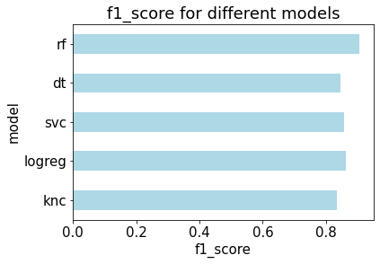

```python
f1_plot = summary.plot.barh(x='model', y='f1_score', color='lightblue', legend=None)
plt.xlabel('f1_score')
plt.title('f1_score for different models')
plt.show()
```

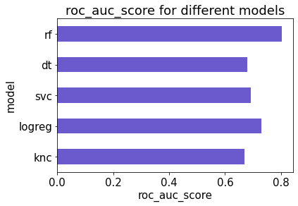

```python
roc_plot = summary.plot.barh(x='model', y='roc_auc_score', color='slateblue', legend=None)
plt.xlabel('roc_auc_score')
plt.title('roc_auc_score for different models')
plt.show()
```

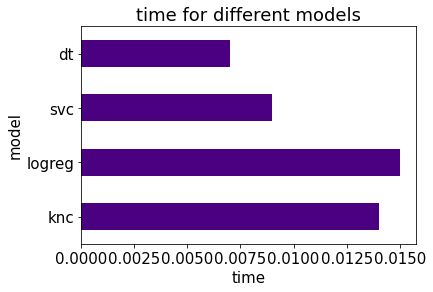

```python
summary_time = summary[summary['time']<0.5] #drop time  for rf as it is much longer

rmse_plot = summary_time.plot.barh(x='model', y='time', color='indigo', legend=None)
plt.xlabel('time')
plt.title('time for different models')
plt.show()
```

Seems like the time it takes for a model to run is not always the same. In general though we can say that the rf model seem to perform better, it is though slower and might be important in some cases.

# Best Feature selection using SelectKBest

```python
#use selectkbest for find the best features with this method
# I was receiving an error that I can have negative values so I will use the data for finding the best k before scaling

from sklearn.feature_selection import SelectKBest
from sklearn.feature_selection import chi2
#create a copy
students_kbest = students.copy()
#drop not needed columns
students_kbest=students_kbest.drop(columns = ['sl_no','salary'])
#replace binary columns with 1 and 0
from sklearn.preprocessing import LabelEncoder
le = LabelEncoder()
students_kbest["gender"] = le.fit_transform(students_kbest["gender"])
students_kbest["ssc_b"] = le.fit_transform(students_kbest["ssc_b"])
students_kbest["hsc_b"] = le.fit_transform(students_kbest["hsc_b"])
students_kbest["workex"] = le.fit_transform(students_kbest["workex"])
students_kbest["specialisation"] = le.fit_transform(students_kbest["specialisation"])
students_kbest["status"] = le.fit_transform(students_kbest["status"])
#one hot encoding from hsc_s and degree_t
students_kbest = pd.get_dummies(students_kbest, columns=['hsc_s'], drop_first = True)
students_kbest = pd.get_dummies(students_kbest, columns=['degree_t'], drop_first = True)

y_kbest = students_kbest['status'].values
X_kbest = students_kbest.drop('status', axis=1).values

fs = SelectKBest(score_func=chi2, k='all')
z = fs.fit_transform(X_kbest, y_kbest)
```

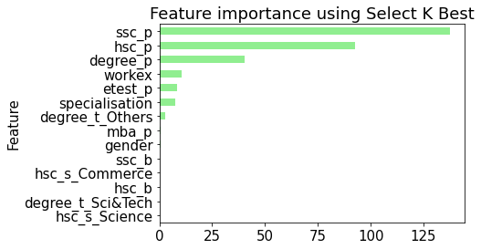

```python
# Create a pd.Series of features importances
importances_SKBest = pd.Series(fs.scores_, index = students_kbest.drop('status', axis=1).columns)
# Sort importances_rf
sorted_importances_SKBest = importances_SKBest.sort_values()
# Make a horizontal bar plot
sorted_importances_SKBest.plot(kind='barh', color='lightgreen')
plt.ylabel('Feature')
plt.title('Feature importance using Select K Best')
plt.show();
```

Based on the feature selection, I will create rf models with 2,3,4,5 and 6 features and see how those models perform and compare them. For comparison reason, I will not tune the models for each but use the best parameters as found in previous stage.

```python
model_1 = students_copy[['ssc_p','hsc_p','status']]
# Create arrays for the features and the response variable
y_model_1 = model_1['status'].values
X_model_1 = model_1.drop('status', axis=1).values

#import packages from sklearn
X_train_model_1, X_test_model_1, y_train_model_1, y_test_model_1 = train_test_split(X_model_1, y_model_1,
test_size = 0.3, random_state=42)
```

```python
#fit a  Random Forest Classifier
import time
from sklearn.metrics import f1_score
from sklearn.metrics import roc_auc_score
start_time = time.time()
rf_model_1 = RandomForestClassifier(max_depth=8,
n_estimators=400,
random_state=42)
rf_model_1.fit(X_train_model_1, y_train_model_1)
# Predict test-set labels
y_pred_rf_model_1 = rf_model_1.predict(X_test_model_1)

roc_auc_score_rf_model_1 = roc_auc_score(y_test_model_1, y_pred_rf_model_1)
f1_score_rf_model_1 = f1_score(y_test_model_1, y_pred_rf_model_1)
end_time = time.time()
time_rf_model_1 = end_time - start_time
print('Test set f1_score of rf: {:.2f}'.format(f1_score_rf_model_1))
print('Test set roc_auc_score of rf: {:.2f}'.format(roc_auc_score_rf_model_1))
print("Result calculated in {:.5f} sec".format(time_rf_model_1))
```

```
Test set f1_score of rf: 0.90
Test set roc_auc_score of rf: 0.77
Result calculated in 0.58724 sec
```

```python
model_2 = students_copy[['ssc_p','hsc_p','degree_p','status']]
# Create arrays for the features and the response variable
y_model_2 = model_2['status'].values
X_model_2 = model_2.drop('status', axis=1).values

#import packages from sklearn
X_train_model_2, X_test_model_2, y_train_model_2, y_test_model_2 = train_test_split(X_model_2, y_model_2,
test_size = 0.3, random_state=42)
```

```python
#fit a  Random Forest Classifier
start_time = time.time()
rf_model_2 = RandomForestClassifier(max_depth=8,
n_estimators=400,
random_state=42)
rf_model_2.fit(X_train_model_2, y_train_model_2)
# Predict test-set labels
y_pred_rf_model_2 = rf_model_2.predict(X_test_model_2)

roc_auc_score_rf_model_2 = roc_auc_score(y_test_model_2, y_pred_rf_model_2)
f1_score_rf_model_2 = f1_score(y_test_model_2, y_pred_rf_model_2)
end_time = time.time()
time_rf_model_2 = end_time - start_time
print('Test set f1_score of rf: {:.2f}'.format(f1_score_rf_model_2))
print('Test set roc_auc_score of rf: {:.2f}'.format(roc_auc_score_rf_model_2))
print("Result calculated in {:.5f} sec".format(time_rf_model_2))
```

```
Test set f1_score of rf: 0.88
Test set roc_auc_score of rf: 0.74
Result calculated in 0.53991 sec
```

```python
model_3 = students_copy[['ssc_p','hsc_p','degree_p','workex','status']]
# Create arrays for the features and the response variable
y_model_3 = model_3['status'].values
X_model_3 = model_3.drop('status', axis=1).values

#import packages from sklearn
X_train_model_3, X_test_model_3, y_train_model_3, y_test_model_3 = train_test_split(X_model_3, y_model_3,
test_size = 0.3, random_state=42)
```

```python
#fit a  Random Forest Classifier
start_time = time.time()
rf_model_3 = RandomForestClassifier(max_depth=8,
n_estimators=400,
random_state=42)
rf_model_3.fit(X_train_model_3, y_train_model_3)
# Predict test-set labels
y_pred_rf_model_3 = rf_model_3.predict(X_test_model_3)

roc_auc_score_rf_model_3 = roc_auc_score(y_test_model_3, y_pred_rf_model_3)
f1_score_rf_model_3 = f1_score(y_test_model_3, y_pred_rf_model_3)
end_time = time.time()
time_rf_model_3 = end_time - start_time
print('Test set f1_score of rf: {:.2f}'.format(f1_score_rf_model_3))
print('Test set roc_auc_score of rf: {:.2f}'.format(roc_auc_score_rf_model_3))
print("Result calculated in {:.5f} sec".format(time_rf_model_3))
```

```
Test set f1_score of rf: 0.86
Test set roc_auc_score of rf: 0.73
Result calculated in 0.56241 sec
```

```python
model_4 = students_copy[['ssc_p','hsc_p','degree_p','workex','etest_p','status']]
# Create arrays for the features and the response variable
y_model_4 = model_4['status'].values
X_model_4 = model_4.drop('status', axis=1).values

#import packages from sklearn
X_train_model_4, X_test_model_4, y_train_model_4, y_test_model_4 = train_test_split(X_model_4, y_model_4,
test_size = 0.3, random_state=42)
```

```python
#fit a  Random Forest Classifier
start_time = time.time()
rf_model_4 = RandomForestClassifier(max_depth=8,
n_estimators=400,
random_state=42)
rf_model_4.fit(X_train_model_4, y_train_model_4)
# Predict test-set labels
y_pred_rf_model_4 = rf_model_4.predict(X_test_model_4)

roc_auc_score_rf_model_4 = roc_auc_score(y_test_model_4, y_pred_rf_model_4)
f1_score_rf_model_4 = f1_score(y_test_model_4, y_pred_rf_model_4)
end_time = time.time()
time_rf_model_4 = end_time - start_time
print('Test set f1_score of rf: {:.2f}'.format(f1_score_rf_model_4))
print('Test set roc_auc_score of rf: {:.2f}'.format(roc_auc_score_rf_model_4))
print("Result calculated in {:.5f} sec".format(time_rf_model_4))
```

```
Test set f1_score of rf: 0.85
Test set roc_auc_score of rf: 0.72
Result calculated in 0.54954 sec
```

```python
model_5 = students_copy[['ssc_p','hsc_p','degree_p','workex','etest_p','specialisation','status']]
# Create arrays for the features and the response variable
y_model_5 = model_5['status'].values
X_model_5 = model_5.drop('status', axis=1).values

#import packages from sklearn
X_train_model_5, X_test_model_5, y_train_model_5, y_test_model_5 = train_test_split(X_model_5, y_model_5,
test_size = 0.3, random_state=42)
```

```python
#fit a  Random Forest Classifier
start_time = time.time()
rf_model_5 = RandomForestClassifier(max_depth=8,
n_estimators=400,
random_state=42)
rf_model_5.fit(X_train_model_5, y_train_model_5)
# Predict test-set labels
y_pred_rf_model_5 = rf_model_5.predict(X_test_model_5)

roc_auc_score_rf_model_5 = roc_auc_score(y_test_model_5, y_pred_rf_model_5)
f1_score_rf_model_5 = f1_score(y_test_model_5, y_pred_rf_model_5)
end_time = time.time()
time_rf_model_5 = end_time - start_time
print('Test set f1_score of rf: {:.2f}'.format(f1_score_rf_model_5))
print('Test set roc_auc_score of rf: {:.2f}'.format(roc_auc_score_rf_model_5))
print("Result calculated in {:.5f} sec".format(time_rf_model_5))
```

```
Test set f1_score of rf: 0.87
Test set roc_auc_score of rf: 0.76
Result calculated in 0.59470 sec
```

```python
# Create summary table
f1_score_rf = [f1_score_rf, f1_score_rf_model_1, f1_score_rf_model_2, f1_score_rf_model_3, f1_score_rf_model_4,f1_score_rf_model_5]
roc_auc_score_rf = [roc_auc_score_rf, roc_auc_score_rf_model_1, roc_auc_score_rf_model_2,
                 roc_auc_score_rf_model_3, roc_auc_score_rf_model_4,roc_auc_score_rf_model_5]
model_rf = ['rf', 'model_1', 'model_2', 'model_3', 'model_4', 'model_5']
time_rf = [time_rf, time_rf_model_1, time_rf_model_2, time_rf_model_3,time_rf_model_4, time_rf_model_5]

zipped_rf = list(zip(model_rf, f1_score_rf,roc_auc_score_rf, time_rf))
summary_rf = pd.DataFrame(zipped_rf, columns=['model', 'f1_score', 'roc_auc_score','time'])
summary_rf
```

|  | model | f1_score | roc_auc_score | time |
| --- | --- | --- | --- | --- |
| 0 | rf | 0.905263 | 0.802778 | 0.551608 |
| 1 | model_1 | 0.895833 | 0.774351 | 0.587240 |
| 2 | model_2 | 0.875000 | 0.739177 | 0.539913 |
| 3 | model_3 | 0.863158 | 0.727814 | 0.562405 |
| 4 | model_4 | 0.851064 | 0.716450 | 0.549538 |
| 5 | model_5 | 0.869565 | 0.764069 | 0.594697 |

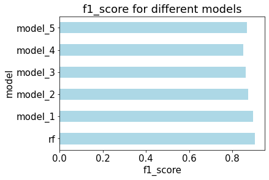

```python
f1_plot_rf = summary_rf.plot.barh(x='model', y='f1_score', color='lightblue', legend=None)
plt.xlabel('f1_score')
plt.title('f1_score for different models')
plt.show()
```

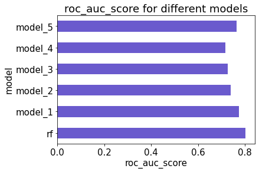

```python
roc_plot_rf = summary_rf.plot.barh(x='model', y='roc_auc_score', color='slateblue', legend=None)
plt.xlabel('roc_auc_score')
plt.title('roc_auc_score for different models')
plt.show()
```

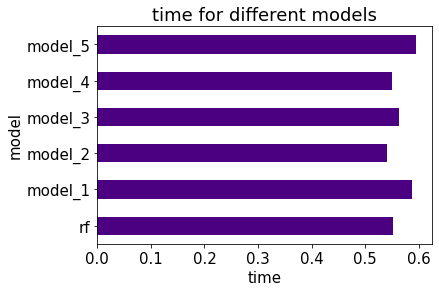

```python
rmse_plot = summary_rf.plot.barh(x='model', y='time', color='indigo', legend=None)
plt.xlabel('time')
plt.title('time for different models')
plt.show()
```

# Summary

In this project, I explored a university student dataset and how possible it is for them to be placed for work placement. I used several models to predict whether they will be placed or not. Seems like the random forest model performs better, but it is slower. I also explore how models with less features perform.